# **Problem Statement**

## Business Context

The EdTech industry has been surging in the past decade immensely, and according to a forecast, the Online Education market would be worth $286.62 bn by 2023 with a compound annual growth rate (CAGR) of 10.26% from 2018 to 2023. The modern era of online education has enforced a lot in its growth and expansion beyond any limit. Due to having many dominant features like ease of information sharing, personalized learning experience, transparency of assessment, etc, it is now preferable to traditional education.

In the present scenario due to the Covid-19, the online education sector has witnessed rapid growth and is attracting a lot of new customers. Due to this rapid growth, many new companies have emerged in this industry. With the availability and ease of use of digital marketing resources, companies can reach out to a wider audience with their offerings. The customers who show interest in these offerings are termed as leads. There are various sources of obtaining leads for Edtech companies, like

- The customer interacts with the marketing front on social media or other online platforms.
- The customer browses the website/app and downloads the brochure
- The customer connects through emails for more information.

The company then nurtures these leads and tries to convert them to paid customers. For this, the representative from the organization connects with the lead on call or through email to share further details.

## Objective

ExtraaLearn is an initial stage startup that offers programs on cutting-edge technologies to students and professionals to help them upskill/reskill. With a large number of leads being generated on a regular basis, one of the issues faced by ExtraaLearn is to identify which of the leads are more likely to convert so that they can allocate resources accordingly. You, as a data scientist at ExtraaLearn, have been provided the leads data to:

- Analyze and build an ML model to help identify which leads are more likely to convert to paid customers,
- Find the factors driving the lead conversion process
- Create a profile of the leads which are likely to convert

## Data Description

The data contains the different attributes of leads and their interaction details with ExtraaLearn. The detailed data dictionary is given below.

- **ID**: ID of the lead.
- **age**: Age of the lead.
- **current_occupation**: Current occupation of the lead. Values include 'Professional','Unemployed',and 'Student'.
- **first_interaction**: How did the lead first interacted with ExtraaLearn. Values include 'Website', 'Mobile App'.
- **profile_completed**: What percentage of profile has been filled by the lead on the website/mobile app. Values include Low - (0-50%), Medium - (50-75%), High (75-100%).
- **website_visits**: How many times has a lead visited the website.
- **time_spent_on_website**: Total time spent on the website in seconds.
- **page_views_per_visit**: Average number of pages on the website viewed during the visits.
- **last_activity**: Last interaction between the lead and ExtraaLearn.
  - Email Activity: Seeking for details about program through email, Representative shared information with lead like brochure of program , etc.
  - Phone Activity: Had a Phone Conversation with representative, Had conversation over SMS with representative, etc.
  - Website Activity: Interacted on live chat with representative, Updated profile on website, etc.
- **print_media_type1**: Flag indicating whether the lead had seen the ad of ExtraaLearn in the Newspaper.
- **print_media_type2**: Flag indicating whether the lead had seen the ad of ExtraaLearn in the Magazine.
- **digital_media**: Flag indicating whether the lead had seen the ad of ExtraaLearn on the digital platforms.
- **educational_channels**: Flag indicating whether the lead had heard about ExtraaLearn in the education channels like online forums, discussion threads, educational websites, etc.
- **referral**: Flag indicating whether the lead had heard about ExtraaLearn through reference.
- **status**: Flag indicating whether the lead was converted to a paid customer or not.

# **Installing and Importing the Necessary libraries**

```python
#Installing the libraries with the specified versions
!pip install numpy==2.0.2 pandas==2.2.2 scikit-learn==1.6.1 matplotlib==3.10.0 seaborn==0.13.2 joblib==1.4.2 xgboost==2.1.4 requests==2.32.3 huggingface_hub==0.30.1 -q
```

[output not shown]

**Note:**

- After running the above cell, kindly restart the notebook kernel (for Jupyter Notebook) or runtime (for Google Colab) and run all cells sequentially from the next cell.
- On executing the above line of code, you might see a warning regarding package dependencies. This error message can be ignored as the above code ensures that all necessary libraries and their dependencies are maintained to successfully execute the code in this notebook.

```python
import warnings
warnings.filterwarnings("ignore")

# Libraries to help with reading and manipulating data
import numpy as np
import pandas as pd

# For splitting the dataset
from sklearn.model_selection import train_test_split

# Libaries to help with data visualization
import matplotlib.pyplot as plt
import seaborn as sns

# Removes the limit for the number of displayed columns
pd.set_option("display.max_columns", None)
# Sets the limit for the number of displayed rows
pd.set_option("display.max_rows", 100)


# Libraries different ensemble classifiers
from sklearn.ensemble import (
    BaggingClassifier,
    RandomForestClassifier,
    AdaBoostClassifier,
    GradientBoostingClassifier,
)
from xgboost import XGBClassifier
from sklearn.tree import DecisionTreeClassifier

# Libraries to get different metric scores
from sklearn.metrics import (
    confusion_matrix,
    accuracy_score,
    precision_score,
    recall_score,
    f1_score,
)

# To create the pipeline
from sklearn.compose import ColumnTransformer, make_column_transformer
from sklearn.pipeline import make_pipeline,Pipeline


# To tune different models and standardize
from sklearn.model_selection import GridSearchCV
from sklearn.preprocessing import StandardScaler,OneHotEncoder

# To serialize the model
import joblib

# os related functionalities
import os

# API request
import requests

# for hugging face space authentication to upload files
from huggingface_hub import login, HfApi
```

# **Loading the dataset**

```python
# uncomment and run the below code snippets if the dataset is present in the Google Drive
from google.colab import drive
drive.mount('/content/drive')
```

## **Overview of the dataset**

```python
# Loading the dataset
data = pd.read_csv("/content/drive/MyDrive/AIML/ExtraaLearn.csv")

print(f"There are {data.shape[0]} rows and {data.shape[1]} columns in the dataset.")
display(data.head())

display(data.info())
display(data.describe(include="all").T)

print("Missing values in each column:")
display(data.isnull().sum())

print("Number of duplicate rows:", data.duplicated().sum())

print("Target variable distribution:")
display(pd.DataFrame({
    "Count": data["status"].value_counts().sort_index(),
    "Percentage": (data["status"].value_counts(normalize=True).sort_index() * 100).round(2),
}))
```

```
There are 4612 rows and 15 columns in the dataset.
```

|  | ID | age | current_occupation | first_interaction | profile_completed | website_visits | time_spent_on_website | page_views_per_visit | last_activity | print_media_type1 | print_media_type2 | digital_media | educational_channels | referral | status |
| --- | --- | --- | --- | --- | --- | --- | --- | --- | --- | --- | --- | --- | --- | --- | --- |
| 0 | EXT001 | 57 | Unemployed | Website | High | 7 | 1639 | 1.861 | Website Activity | Yes | No | Yes | No | No | 1 |
| 1 | EXT002 | 56 | Professional | Mobile App | Medium | 2 | 83 | 0.320 | Website Activity | No | No | No | Yes | No | 0 |
| 2 | EXT003 | 52 | Professional | Website | Medium | 3 | 330 | 0.074 | Website Activity | No | No | Yes | No | No | 0 |
| 3 | EXT004 | 53 | Unemployed | Website | High | 4 | 464 | 2.057 | Website Activity | No | No | No | No | No | 1 |
| 4 | EXT005 | 23 | Student | Website | High | 4 | 600 | 16.914 | Email Activity | No | No | No | No | No | 0 |

```
<class 'pandas.core.frame.DataFrame'>
RangeIndex: 4612 entries, 0 to 4611
Data columns (total 15 columns):
 #   Column                 Non-Null Count  Dtype
---  ------                 --------------  -----
 0   ID                     4612 non-null   object
 1   age                    4612 non-null   int64
 2   current_occupation     4612 non-null   object
 3   first_interaction      4612 non-null   object
 4   profile_completed      4612 non-null   object
 5   website_visits         4612 non-null   int64
 6   time_spent_on_website  4612 non-null   int64
 7   page_views_per_visit   4612 non-null   float64
 8   last_activity          4612 non-null   object
 9   print_media_type1      4612 non-null   object
 10  print_media_type2      4612 non-null   object
 11  digital_media          4612 non-null   object
 12  educational_channels   4612 non-null   object
 13  referral               4612 non-null   object
 14  status                 4612 non-null   int64
dtypes: float64(1), int64(4), object(10)
memory usage: 540.6+ KB
```

```
None
```

|  | count | unique | top | freq | mean | std | min | 25% | 50% | 75% | max |
| --- | --- | --- | --- | --- | --- | --- | --- | --- | --- | --- | --- |
| ID | 4612 | 4612 | EXT4612 | 1 | NaN | NaN | NaN | NaN | NaN | NaN | NaN |
| age | 4612.0 | NaN | NaN | NaN | 46.201214 | 13.161454 | 18.0 | 36.0 | 51.0 | 57.0 | 63.0 |
| current_occupation | 4612 | 3 | Professional | 2616 | NaN | NaN | NaN | NaN | NaN | NaN | NaN |
| first_interaction | 4612 | 2 | Website | 2542 | NaN | NaN | NaN | NaN | NaN | NaN | NaN |
| profile_completed | 4612 | 3 | High | 2264 | NaN | NaN | NaN | NaN | NaN | NaN | NaN |
| website_visits | 4612.0 | NaN | NaN | NaN | 3.566782 | 2.829134 | 0.0 | 2.0 | 3.0 | 5.0 | 30.0 |
| time_spent_on_website | 4612.0 | NaN | NaN | NaN | 724.011275 | 743.828683 | 0.0 | 148.75 | 376.0 | 1336.75 | 2537.0 |
| page_views_per_visit | 4612.0 | NaN | NaN | NaN | 3.026126 | 1.968125 | 0.0 | 2.07775 | 2.792 | 3.75625 | 18.434 |
| last_activity | 4612 | 3 | Email Activity | 2278 | NaN | NaN | NaN | NaN | NaN | NaN | NaN |
| print_media_type1 | 4612 | 2 | No | 4115 | NaN | NaN | NaN | NaN | NaN | NaN | NaN |
| print_media_type2 | 4612 | 2 | No | 4379 | NaN | NaN | NaN | NaN | NaN | NaN | NaN |
| digital_media | 4612 | 2 | No | 4085 | NaN | NaN | NaN | NaN | NaN | NaN | NaN |
| educational_channels | 4612 | 2 | No | 3907 | NaN | NaN | NaN | NaN | NaN | NaN | NaN |
| referral | 4612 | 2 | No | 4519 | NaN | NaN | NaN | NaN | NaN | NaN | NaN |
| status | 4612.0 | NaN | NaN | NaN | 0.298569 | 0.45768 | 0.0 | 0.0 | 0.0 | 1.0 | 1.0 |

```
Missing values in each column:
```

|  | 0 |
| --- | --- |
| ID | 0 |
| age | 0 |
| current_occupation | 0 |
| first_interaction | 0 |
| profile_completed | 0 |
| website_visits | 0 |
| time_spent_on_website | 0 |
| page_views_per_visit | 0 |
| last_activity | 0 |
| print_media_type1 | 0 |
| print_media_type2 | 0 |
| digital_media | 0 |
| educational_channels | 0 |
| referral | 0 |
| status | 0 |

**dtype:** int64

```
Number of duplicate rows: 0
Target variable distribution:
```

| status | Count | Percentage |
| --- | --- | --- |
| 0 | 3235 | 70.14 |
| 1 | 1377 | 29.86 |

**Observations**

- The dataset contains **4,612 rows and 15 columns**.
- There are **no missing values** in any column, so imputation is not required.
- There are **no duplicate rows**, which means the data appears clean at the row level.
- The `ID` column has **4,612 unique values**, so it is only an identifier and should likely be dropped before modeling.
- The dataset has **5 numerical columns** and **10 categorical/object columns**.
- The target variable `status` is binary, with:
  - `0`: **3,235 records** or **70.14%**
  - `1`: **1,377 records** or **29.86%**
- This shows a **moderate class imbalance**, so model evaluation should not rely only on accuracy.
- The average age is about **46 years**, with ages ranging from **18 to 63**.
- Most users are **Professionals**, making up the largest occupation group.
- Most first interactions happened through the **Website** rather than the Mobile App.
- `website_visits`, `time_spent_on_website`, and `page_views_per_visit` have high maximum values, suggesting possible **right-skewness or outliers**.
- Most marketing channel columns such as `print_media_type1`, `print_media_type2`, `digital_media`, `educational_channels`, and `referral` are dominated by **No**, meaning fewer users came through these channels.

# **Exploratory Data Analysis**

**The below functions need to be defined to carry out the EDA.**

```python
def histogram_boxplot(data, feature, figsize=(15, 10), kde=False, bins=None):
    """
    Boxplot and histogram combined

    data: dataframe
    feature: dataframe column
    figsize: size of figure (default (15,10))
    kde: whether to show the density curve (default False)
    bins: number of bins for histogram (default None)
    """
    f2, (ax_box2, ax_hist2) = plt.subplots(
        nrows=2,  # Number of rows of the subplot grid= 2
        sharex=True,  # x-axis will be shared among all subplots
        gridspec_kw={"height_ratios": (0.25, 0.75)},
        figsize=figsize,
    )  # creating the 2 subplots
    sns.boxplot(
        data=data, x=feature, ax=ax_box2, showmeans=True, color="violet"
    )  # boxplot will be created and a triangle will indicate the mean value of the column
    sns.histplot(
        data=data, x=feature, kde=kde, ax=ax_hist2, bins=bins
    ) if bins else sns.histplot(
        data=data, x=feature, kde=kde, ax=ax_hist2
    )  # For histogram
    ax_hist2.axvline(
        data[feature].mean(), color="green", linestyle="--"
    )  # Add mean to the histogram
    ax_hist2.axvline(
        data[feature].median(), color="black", linestyle="-"
    )  # Add median to the histogram
```

```python
# function to create labeled barplots


def labeled_barplot(data, feature, perc=False, n=None):
    """
    Barplot with percentage at the top

    data: dataframe
    feature: dataframe column
    perc: whether to display percentages instead of count (default is False)
    n: displays the top n category levels (default is None, i.e., display all levels)
    """

    total = len(data[feature])  # length of the column
    count = data[feature].nunique()
    if n is None:
        plt.figure(figsize=(count + 2, 6))
    else:
        plt.figure(figsize=(n + 2, 6))

    plt.xticks(rotation=90, fontsize=15)
    ax = sns.countplot(
        data=data,
        x=feature,
        order=data[feature].value_counts().index[:n],
    )

    for p in ax.patches:
        if perc == True:
            label = "{:.1f}%".format(
                100 * p.get_height() / total
            )  # percentage of each class of the category
        else:
            label = p.get_height()  # count of each level of the category

        x = p.get_x() + p.get_width() / 2  # width of the plot
        y = p.get_height()  # height of the plot

        ax.annotate(
            label,
            (x, y),
            ha="center",
            va="center",
            size=12,
            xytext=(0, 5),
            textcoords="offset points",
        )  # annotate the percentage

    plt.show()  # show the plot
```

```python
def stacked_barplot(data, predictor, target):
    """
    Print the category counts and plot a stacked bar chart

    data: dataframe
    predictor: independent variable
    target: target variable
    """
    count = data[predictor].nunique()
    sorter = data[target].value_counts().index[-1]
    tab1 = pd.crosstab(data[predictor], data[target], margins=True).sort_values(
        by=sorter, ascending=False
    )
    print(tab1)
    print("-" * 120)
    tab = pd.crosstab(data[predictor], data[target], normalize="index").sort_values(
        by=sorter, ascending=False
    )
    tab.plot(kind="bar", stacked=True, figsize=(count + 5, 5))
    plt.legend(
        loc="lower left", frameon=False,
    )
    plt.legend(loc="upper left", bbox_to_anchor=(1, 1))
    plt.show()
```

```python
### function to plot distributions wrt target


def distribution_plot_wrt_target(data, predictor, target):

    fig, axs = plt.subplots(2, 2, figsize=(12, 10))

    target_uniq = data[target].unique()

    axs[0, 0].set_title("Distribution of target for target=" + str(target_uniq[0]))
    sns.histplot(
        data=data[data[target] == target_uniq[0]],
        x=predictor,
        kde=True,
        ax=axs[0, 0],
        color="teal",
        stat="density",
    )

    axs[0, 1].set_title("Distribution of target for target=" + str(target_uniq[1]))
    sns.histplot(
        data=data[data[target] == target_uniq[1]],
        x=predictor,
        kde=True,
        ax=axs[0, 1],
        color="orange",
        stat="density",
    )

    axs[1, 0].set_title("Boxplot w.r.t target")
    sns.boxplot(data=data, x=target, y=predictor, ax=axs[1, 0])

    axs[1, 1].set_title("Boxplot (without outliers) w.r.t target")
    sns.boxplot(
        data=data,
        x=target,
        y=predictor,
        ax=axs[1, 1],
        showfliers=False,
    )

    plt.tight_layout()
    plt.show()
```

### Univariate Analysis

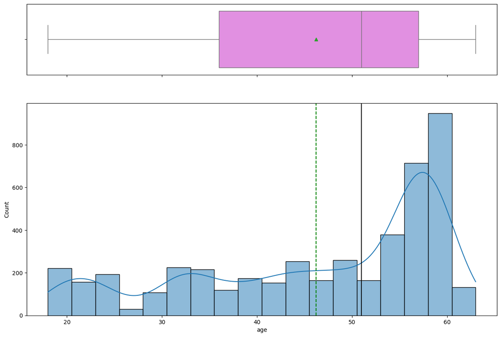

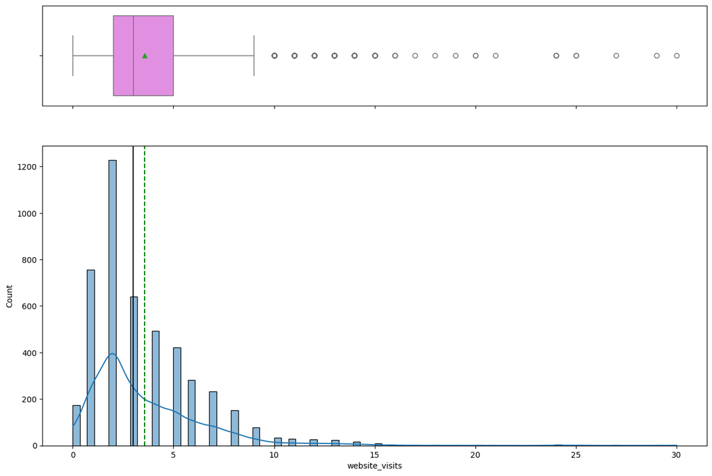

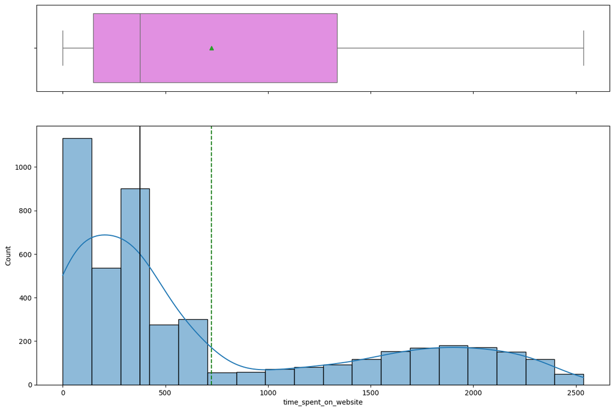

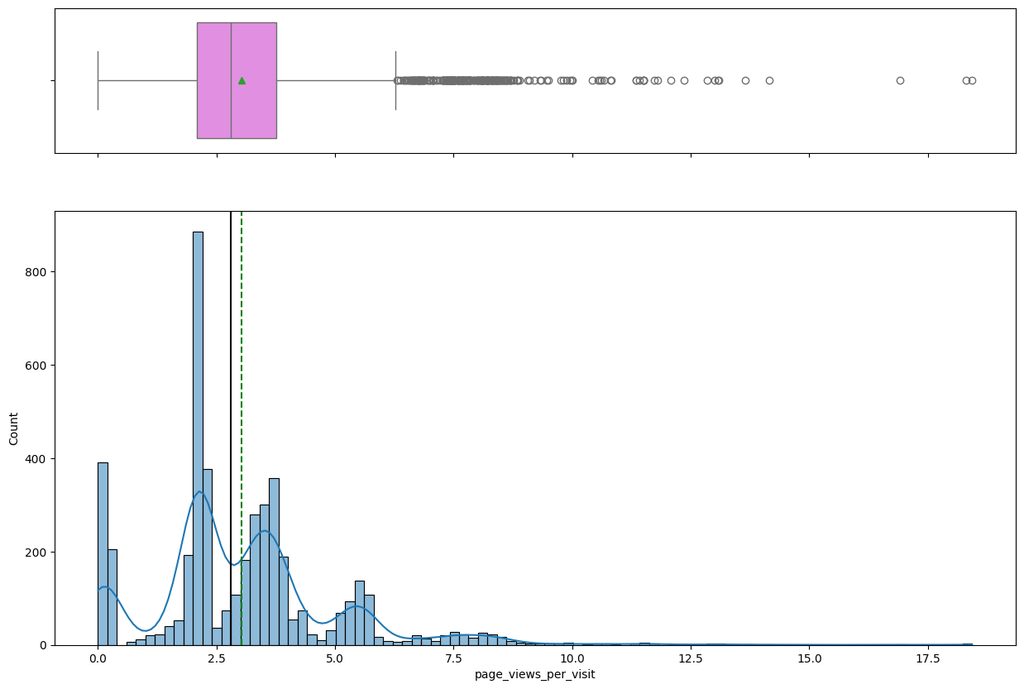

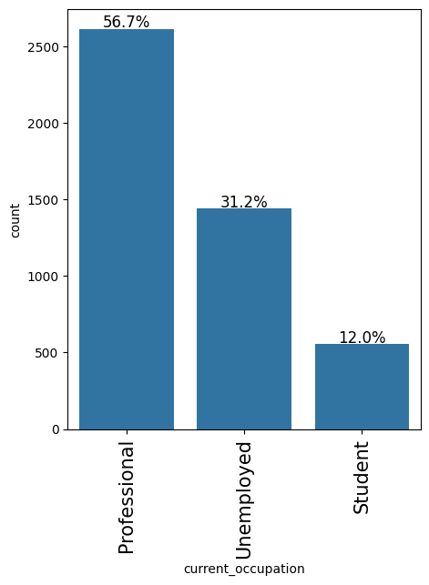

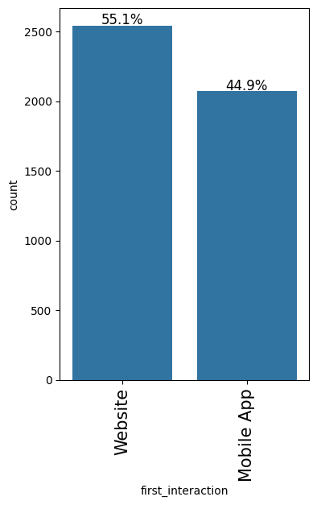

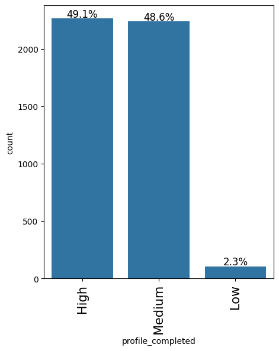

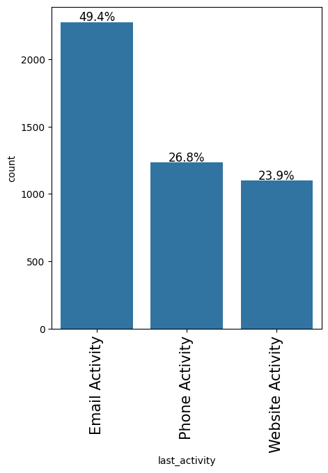

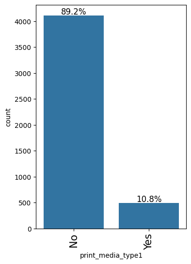

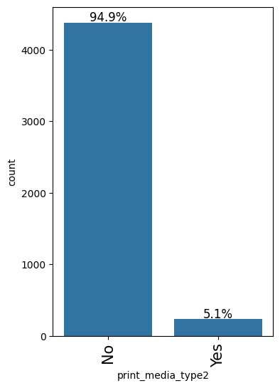

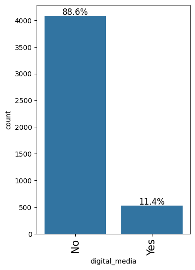

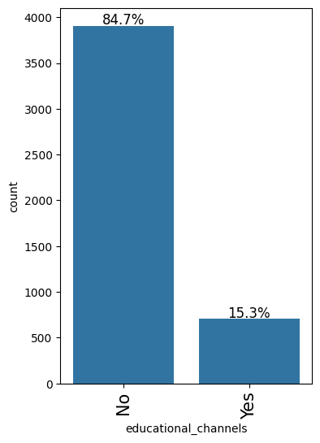

[2 more figures not shown]

```python
numerical_columns = ["age", "website_visits", "time_spent_on_website", "page_views_per_visit"]
categorical_columns = [
    "current_occupation",
    "first_interaction",
    "profile_completed",
    "last_activity",
    "print_media_type1",
    "print_media_type2",
    "digital_media",
    "educational_channels",
    "referral",
]

for column in numerical_columns:
    histogram_boxplot(data, column, kde=True)

for column in categorical_columns + ["status"]:
    labeled_barplot(data, column, perc=True)
```

**Observations From Age Distribution**

- The `age` variable ranges from about **18 to 63 years**.
- Most individuals are concentrated in the **mid-50s to early-60s** age range.
- The **mean age is around 46**, while the **median is around 51**, meaning the distribution is **left-skewed**.
- The boxplot shows that the middle 50% of ages lie roughly between **36 and 57 years**.
- There are **no clear outliers** in the age column.
- The histogram suggests the age distribution is **not normally distributed**, with a strong concentration among older individuals and fewer younger individuals.

**Observations From Website Visits**

- The `website_visits` variable ranges from **0 to 30 visits**.
- Most users visited the website only a few times, mainly between **1 and 5 visits**.
- The distribution is **strongly right-skewed**, with a long tail toward higher visit counts.
- The **mean is higher than the median**, indicating that a small number of users with many visits are pulling the average upward.
- The boxplot shows several **high-value outliers**, especially above roughly **9 visits**.
- Very few users visited the website more than **10 times**.
- Since the feature is skewed and contains outliers, it may benefit from transformation or outlier treatment before modeling.

**Observations From Time Spent on Website**

- `time_spent_on_website` ranges from **0 to about 2,537 seconds**.
- Most users spend relatively low time on the website, especially between **0 and 500 seconds**.
- The distribution is **right-skewed**, with a long tail toward users who spend much more time.
- The **mean is greater than the median**, showing that high-time users are pulling the average upward.
- The boxplot shows a wide spread, meaning user engagement time varies strongly across visitors.
- There are **no clear extreme outliers**, but there are many high-duration values.
- This feature may be useful for predicting `status`, since higher time spent can indicate stronger user engagement.

**Observations From Page Views Per Visit**

- `page_views_per_visit` ranges from **0 to about 18.4 pages**.
- Most users view around **2 to 4 pages per visit**.
- The distribution is **right-skewed**, with a long tail toward very high page views.
- The **mean is slightly higher than the median**, suggesting that high page-view users pull the average upward.
- The boxplot shows many **upper-end outliers**, especially beyond roughly **6 page views per visit**.
- There are also some users with **0 page views**, which may represent very short visits, tracking issues, or inactive sessions.
- This feature likely reflects engagement level and may be useful for predicting `status`.

**Observations From Categorical Variables**

- Most individuals are **Professionals** at **56.7%**, followed by **Unemployed** at **31.2%** and **Students** at **12.0%**.
- The first interaction channel is fairly balanced, but **Website** is slightly higher at **55.1%** compared to **Mobile App** at **44.9%**.
- Most users have either **High** or **Medium** profile completion, at **49.1%** and **48.6%** respectively. Very few users have **Low** profile completion, only **2.3%**.
- For `last_activity`, **Email Activity** is the most common at **49.4%**, followed by **Phone Activity** at **26.8%** and **Website Activity** at **23.9%**.
- Most users were **not reached through digital media**, with **88.6% No** and only **11.4% Yes**.
- Most users were also **not reached through educational channels**, with **84.7% No** and **15.3% Yes**.
- Referrals are very rare: **98.0% No** and only **2.0% Yes**.
- The target variable `status` is imbalanced: **70.1% belong to class 0**, while **29.9% belong to class 1**.
- Overall, the dataset is dominated by professionals, website-based first interactions, high/medium profile completion, and non-referral/non-media sources.

### Bivariate Analysis

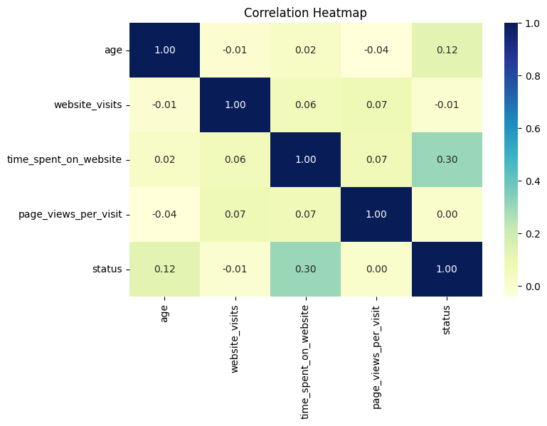

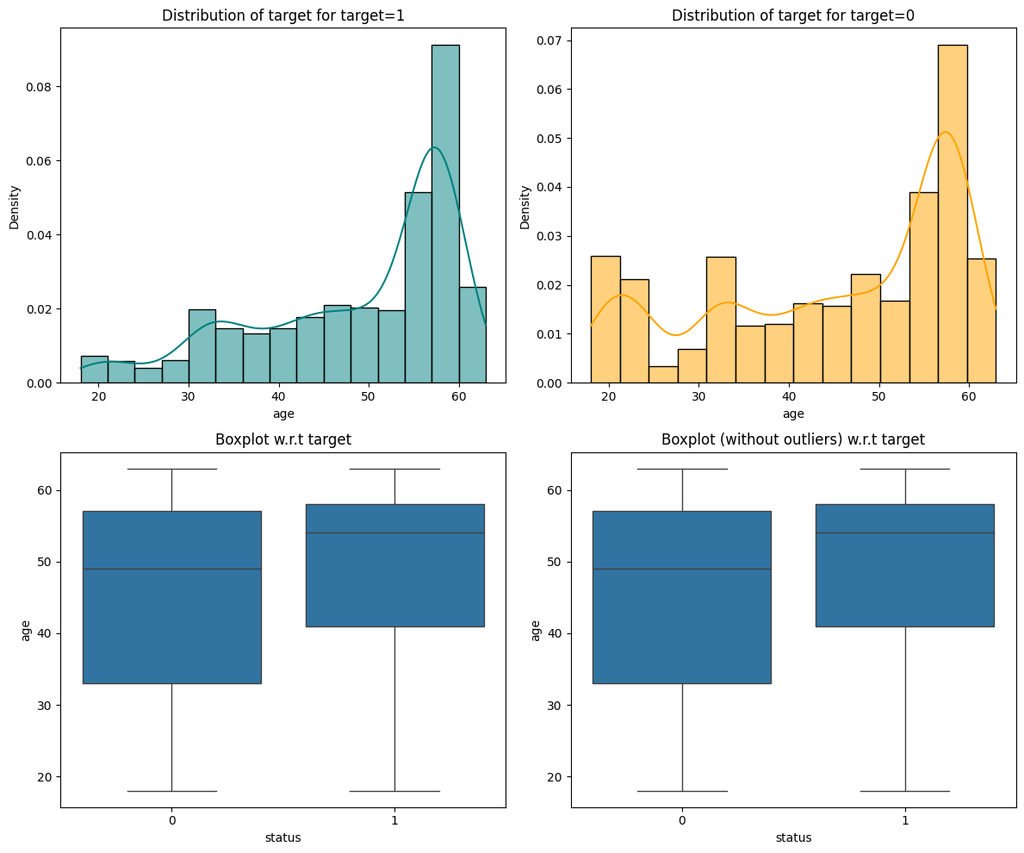

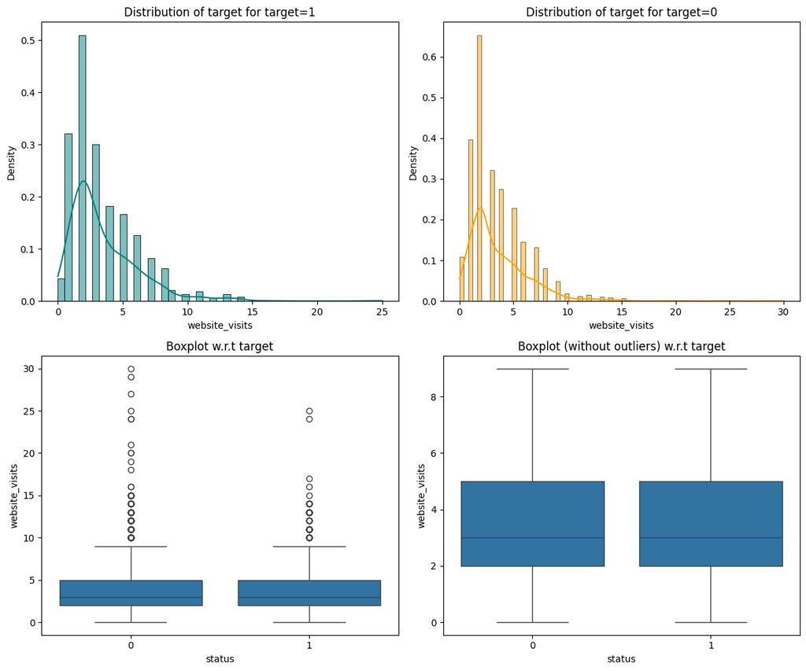

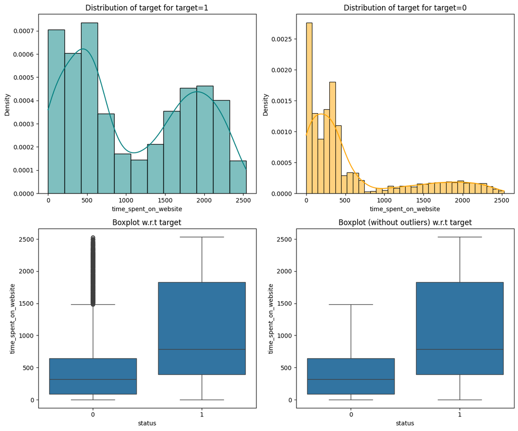

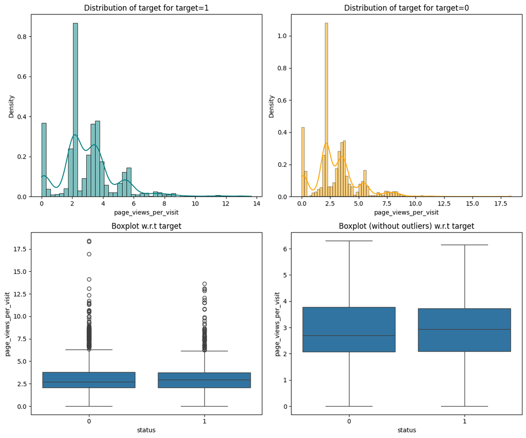

```
status                 0     1   All
current_occupation
All                 3235  1377  4612
Professional        1687   929  2616
Unemployed          1058   383  1441
Student              490    65   555
------------------------------------------------------------------------------------------------------------------------
```

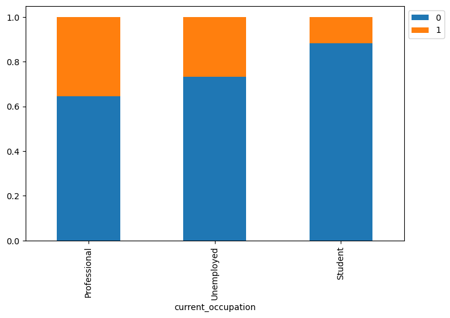

```
status                0     1   All
first_interaction
All                3235  1377  4612
Website            1383  1159  2542
Mobile App         1852   218  2070
------------------------------------------------------------------------------------------------------------------------
```

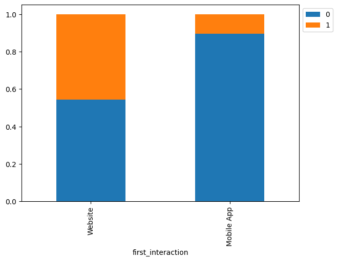

```
status                0     1   All
profile_completed
All                3235  1377  4612
High               1318   946  2264
Medium             1818   423  2241
Low                  99     8   107
------------------------------------------------------------------------------------------------------------------------
```

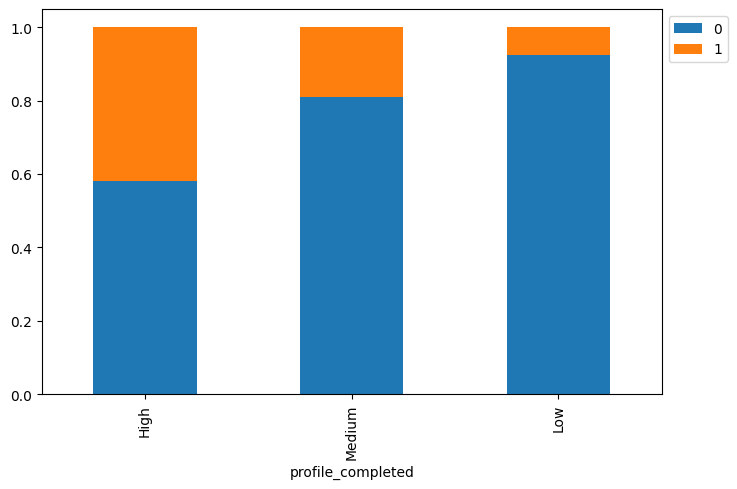

```
status               0     1   All
last_activity
All               3235  1377  4612
Email Activity    1587   691  2278
Website Activity   677   423  1100
Phone Activity     971   263  1234
------------------------------------------------------------------------------------------------------------------------
```

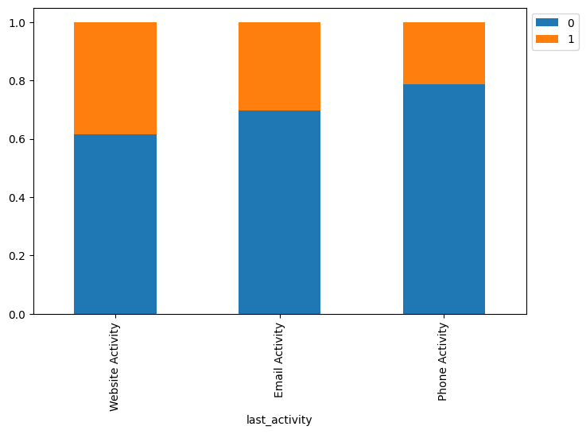

```
status                0     1   All
print_media_type1
All                3235  1377  4612
No                 2897  1218  4115
Yes                 338   159   497
------------------------------------------------------------------------------------------------------------------------
```

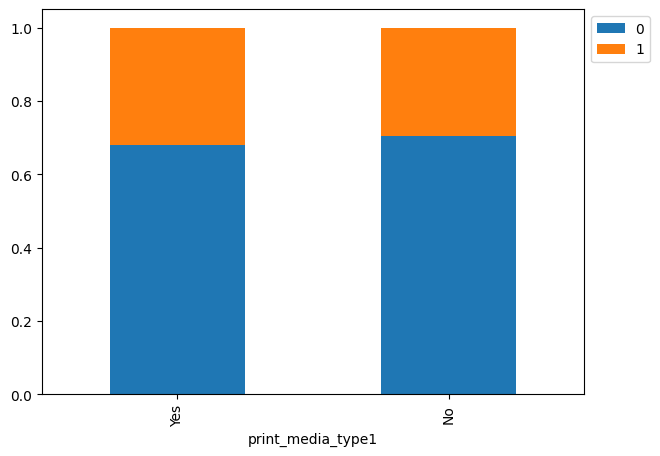

```
status                0     1   All
print_media_type2
All                3235  1377  4612
No                 3077  1302  4379
Yes                 158    75   233
------------------------------------------------------------------------------------------------------------------------
```

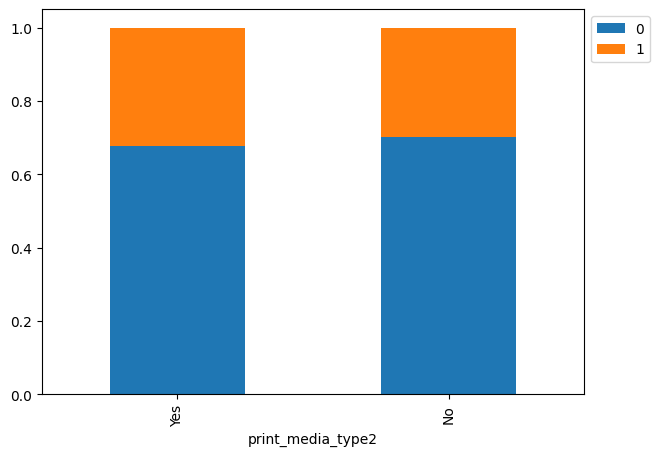

```
status            0     1   All
digital_media
All            3235  1377  4612
No             2876  1209  4085
Yes             359   168   527
------------------------------------------------------------------------------------------------------------------------
```

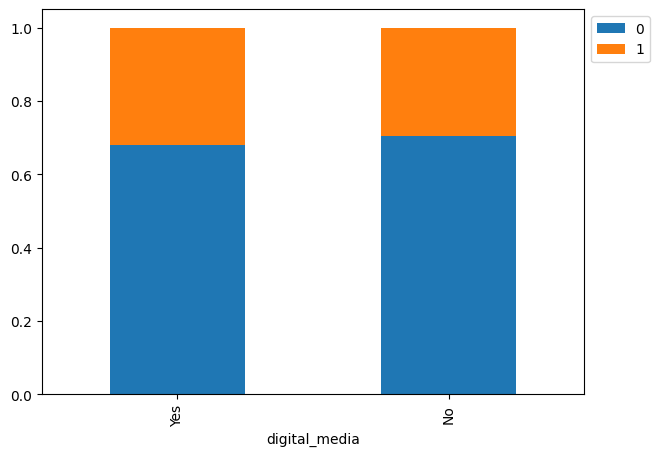

```
status                   0     1   All
educational_channels
All                   3235  1377  4612
No                    2727  1180  3907
Yes                    508   197   705
------------------------------------------------------------------------------------------------------------------------
```

[2 more figures not shown]

|  | Feature | current_occupation | Count | Conversion_Rate |
| --- | --- | --- | --- | --- |
| 0 | current_occupation | Professional | 2616 | 35.51 |
| 2 | current_occupation | Unemployed | 1441 | 26.58 |
| 1 | current_occupation | Student | 555 | 11.71 |

|  | Feature | first_interaction | Count | Conversion_Rate |
| --- | --- | --- | --- | --- |
| 1 | first_interaction | Website | 2542 | 45.59 |
| 0 | first_interaction | Mobile App | 2070 | 10.53 |

|  | Feature | profile_completed | Count | Conversion_Rate |
| --- | --- | --- | --- | --- |
| 0 | profile_completed | High | 2264 | 41.78 |
| 2 | profile_completed | Medium | 2241 | 18.88 |
| 1 | profile_completed | Low | 107 | 7.48 |

|  | Feature | last_activity | Count | Conversion_Rate |
| --- | --- | --- | --- | --- |
| 2 | last_activity | Website Activity | 1100 | 38.45 |
| 0 | last_activity | Email Activity | 2278 | 30.33 |
| 1 | last_activity | Phone Activity | 1234 | 21.31 |

|  | Feature | print_media_type1 | Count | Conversion_Rate |
| --- | --- | --- | --- | --- |
| 1 | print_media_type1 | Yes | 497 | 31.99 |
| 0 | print_media_type1 | No | 4115 | 29.60 |

|  | Feature | print_media_type2 | Count | Conversion_Rate |
| --- | --- | --- | --- | --- |
| 1 | print_media_type2 | Yes | 233 | 32.19 |
| 0 | print_media_type2 | No | 4379 | 29.73 |

|  | Feature | digital_media | Count | Conversion_Rate |
| --- | --- | --- | --- | --- |
| 1 | digital_media | Yes | 527 | 31.88 |
| 0 | digital_media | No | 4085 | 29.60 |

|  | Feature | educational_channels | Count | Conversion_Rate |
| --- | --- | --- | --- | --- |
| 0 | educational_channels | No | 3907 | 30.20 |
| 1 | educational_channels | Yes | 705 | 27.94 |

|  | Feature | referral | Count | Conversion_Rate |
| --- | --- | --- | --- | --- |
| 1 | referral | Yes | 93 | 67.74 |
| 0 | referral | No | 4519 | 29.08 |

```python
plt.figure(figsize=(8, 5))
sns.heatmap(data[numerical_columns + ["status"]].corr(), annot=True, cmap="YlGnBu", fmt=".2f")
plt.title("Correlation Heatmap")
plt.show()

for column in numerical_columns:
    distribution_plot_wrt_target(data, column, "status")

for column in categorical_columns:
    stacked_barplot(data, column, "status")

conversion_by_category = []
for column in categorical_columns:
    temp = (
        data.groupby(column)["status"]
        .agg(Count="count", Conversion_Rate="mean")
        .reset_index()
    )
    temp["Feature"] = column
    temp["Conversion_Rate"] = (temp["Conversion_Rate"] * 100).round(2)
    conversion_by_category.append(temp[["Feature", column, "Count", "Conversion_Rate"]])

for table in conversion_by_category:
    display(table.sort_values("Conversion_Rate", ascending=False))
```

**Bivariate Observations With Target**

- `time_spent_on_website` has the strongest numerical relationship with `status`, with a correlation of about **0.30**. Users who converted generally spent much more time on the website.
- `age` has a weak positive relationship with `status` at about **0.12**. Converted users appear slightly older on average.
- `website_visits` and `page_views_per_visit` show almost **no linear correlation** with `status`, so visit count alone may not strongly separate converters from non-converters.
- The numerical features have low correlations with each other, so there is no major multicollinearity concern among them.

**Categorical Observations**

- `first_interaction` is highly important: users whose first interaction was through the **Website** converted at **45.59%**, compared to only **10.53%** for **Mobile App**.
- `profile_completed` shows a clear pattern: **High** profile completion has the highest conversion rate at **41.78%**, followed by **Medium** at **18.88%**, and **Low** at **7.48%**.
- `last_activity` also matters. **Website Activity** has the highest conversion rate at **38.45%**, followed by **Email Activity** at **30.33%**, and **Phone Activity** at **21.31%**.
- `referral` has a very high conversion rate: **67.74%** for referred users versus **29.08%** for non-referred users. However, only **93 users** came through referrals, so this group is small.
- `print_media_type1`, `print_media_type2`, and `digital_media` show only small differences in conversion rates, so they may have weaker predictive power.
- `educational_channels` does not appear to improve conversion; users marked **Yes** have a slightly lower conversion rate than those marked **No**.

Overall, the strongest predictors appear to be **first interaction channel**, **profile completion level**, **time spent on website**, **last activity**, and **referral**.

# **Data Preprocessing**

## Outlier Check

|  | Feature | Lower Bound | Upper Bound | Outlier Count | Outlier % |
| --- | --- | --- | --- | --- | --- |
| 0 | age | 4.50 | 88.500 | 0 | 0.00 |
| 1 | website_visits | -2.50 | 9.500 | 154 | 3.34 |
| 2 | time_spent_on_website | -1633.25 | 3118.750 | 0 | 0.00 |
| 3 | page_views_per_visit | -0.44 | 6.274 | 257 | 5.57 |

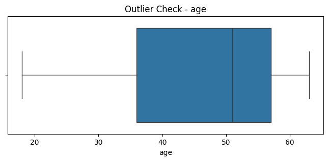

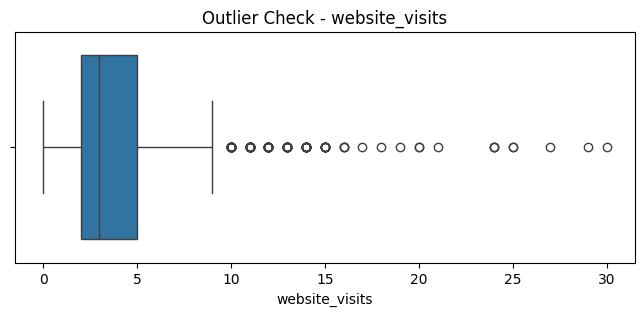

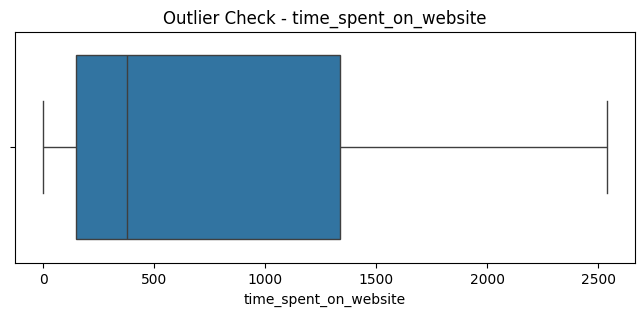

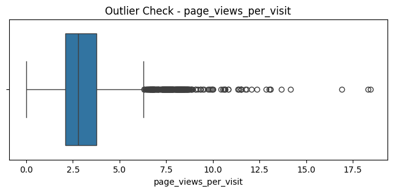

```python
outlier_summary = []
for column in numerical_columns:
    q1 = data[column].quantile(0.25)
    q3 = data[column].quantile(0.75)
    iqr = q3 - q1
    lower_bound = q1 - 1.5 * iqr
    upper_bound = q3 + 1.5 * iqr
    outlier_count = data[(data[column] < lower_bound) | (data[column] > upper_bound)].shape[0]
    outlier_summary.append(
        {
            "Feature": column,
            "Lower Bound": lower_bound,
            "Upper Bound": upper_bound,
            "Outlier Count": outlier_count,
            "Outlier %": round(outlier_count / data.shape[0] * 100, 2),
        }
    )

outlier_summary = pd.DataFrame(outlier_summary)
display(outlier_summary)

for column in numerical_columns:
    plt.figure(figsize=(8, 3))
    sns.boxplot(data=data, x=column)
    plt.title(f"Outlier Check - {column}")
    plt.show()

# The selected tree-based models are robust to outliers, so no outlier capping is applied.
```

**Outlier Observations**

- `age` has **no outliers**, with all values falling within the acceptable range of **4.50 to 88.50**.
- `time_spent_on_website` also has **no outliers**, based on the calculated bounds of **-1633.25 to 3118.75**.
- `website_visits` has **154 outliers**, representing **3.34%** of the dataset. These are users with unusually high numbers of visits, above the upper bound of **9.50**.
- `page_views_per_visit` has **257 outliers**, representing **5.57%** of the dataset. These are users with unusually high page views per visit, above the upper bound of **6.274**.
- Since the outlier percentages are relatively small, especially below **6%**, they may not need to be removed immediately.
- The outliers in `website_visits` and `page_views_per_visit` could represent highly engaged users, so they may contain useful business information.
- For modeling, it may be better to use **outlier treatment such as capping/winsorization** rather than deleting these records.

## Data Preparation for modeling

- We want to predict which lead is more likely to be converted.
- Before we proceed to build a model, we'll have to encode categorical features.
- We'll split the data into train and test to be able to evaluate the model that we build on the train data.

```python
X = data.drop(["ID", "status"], axis=1)
y = data["status"]

X_train, X_test, y_train, y_test = train_test_split(
    X,
    y,
    test_size=0.30,
    random_state=1,
    stratify=y,
)

print("Training data shape:", X_train.shape)
print("Test data shape:", X_test.shape)
print("Training target distribution:")
display(y_train.value_counts(normalize=True).sort_index().mul(100).round(2))
print("Test target distribution:")
display(y_test.value_counts(normalize=True).sort_index().mul(100).round(2))
```

```
Training data shape: (3228, 13)
Test data shape: (1384, 13)
Training target distribution:
```

| status | proportion |
| --- | --- |
| 0 | 70.14 |
| 1 | 29.86 |

**dtype:** float64

```
Test target distribution:
```

| status | proportion |
| --- | --- |
| 0 | 70.16 |
| 1 | 29.84 |

**dtype:** float64

**Train-Test Split Observations**

- The data was split into **3,228 training records** and **1,384 test records**.
- Both training and test sets contain **13 features**, meaning unnecessary columns such as `ID` were likely removed before modeling.
- The target distribution is almost identical in both sets:
  - Training set: **70.14% class 0**, **29.86% class 1**
  - Test set: **70.16% class 0**, **29.84% class 1**
- This shows that the split was likely **stratified**, preserving the original class balance.
- The dataset still has a **moderate class imbalance**, so metrics such as **precision, recall, F1-score, ROC-AUC**, and the confusion matrix should be considered in addition to accuracy.
- Overall, the train-test split looks appropriate and reliable for model evaluation.

## **Data Pre-processing Pipeline**

```python
numeric_features = X.select_dtypes(include=np.number).columns.tolist()
categorical_features = X.select_dtypes(include=["object", "category"]).columns.tolist()

preprocessor = ColumnTransformer(
    transformers=[
        ("num", StandardScaler(), numeric_features),
        ("cat", OneHotEncoder(handle_unknown="ignore"), categorical_features),
    ],
    remainder="drop",
)

print("Numeric features:", numeric_features)
print("Categorical features:", categorical_features)
```

```
Numeric features: ['age', 'website_visits', 'time_spent_on_website', 'page_views_per_visit']
Categorical features: ['current_occupation', 'first_interaction', 'profile_completed', 'last_activity', 'print_media_type1', 'print_media_type2', 'digital_media', 'educational_channels', 'referral']
```

**Feature Type Observations**

- There are **4 numeric features**: `age`, `website_visits`, `time_spent_on_website`, and `page_views_per_visit`.
- There are **9 categorical features**, including occupation, interaction channel, activity type, media exposure, educational channels, and referral.
- The target column `status` is correctly excluded from the feature lists.
- The `ID` column is also excluded, which is appropriate because it is only a unique identifier and does not carry predictive meaning.
- Numeric features should be scaled if models sensitive to feature magnitude are used, such as Logistic Regression, KNN, or SVM.
- Categorical features need to be encoded before modeling, using methods such as one-hot encoding.
- This separation is suitable for building a preprocessing pipeline with numeric and categorical transformations handled separately.

# **Model Building**

## Model Evaluation Criterion

The business objective is to identify leads that are likely to become paid customers so that ExtraaLearn can prioritize follow-up efforts. Missing a good lead may mean lost revenue, while marking too many weak leads as high priority can waste the sales team's time.

For this reason, **F1-score** is used as the primary model selection metric because it balances **precision** and **recall** for the converted class. Recall is also monitored closely because the company should avoid missing leads with a strong chance of conversion.

## Define functions for Model Evaluation

```python
# Function to compute different metrics to check performance of a classification model
def model_performance_classification(model, predictors, target):
    """
    Function to compute different metrics to check classifier model performance

    model: classifier
    predictors: independent variables
    target: dependent variable
    """

    pred = model.predict(predictors)

    acc = accuracy_score(target, pred)
    recall = recall_score(target, pred)
    precision = precision_score(target, pred)
    f1 = f1_score(target, pred)

    df_perf = pd.DataFrame(
        {"Accuracy": acc, "Recall": recall, "Precision": precision, "F1": f1},
        index=[0],
    )

    return df_perf


def confusion_matrix_sklearn(model, predictors, target):
    """Plot a confusion matrix for a classification model."""
    pred = model.predict(predictors)
    cm = confusion_matrix(target, pred)
    plt.figure(figsize=(5, 4))
    sns.heatmap(
        cm,
        annot=True,
        fmt="d",
        cmap="Blues",
        xticklabels=["Not Converted", "Converted"],
        yticklabels=["Not Converted", "Converted"],
    )
    plt.ylabel("Actual")
    plt.xlabel("Predicted")
    plt.show()
```

## Random Forest Model

```python
rf_model = Pipeline(
    steps=[
        ("preprocessor", preprocessor),
        (
            "model",
            RandomForestClassifier(
                random_state=1,
                n_estimators=200,
                class_weight="balanced",
            ),
        ),
    ]
)

rf_model.fit(X_train, y_train)
```

```
Pipeline(steps=[('preprocessor',
                 ColumnTransformer(transformers=[('num', StandardScaler(),
                                                  ['age', 'website_visits',
                                                   'time_spent_on_website',
                                                   'page_views_per_visit']),
                                                 ('cat',
                                                  OneHotEncoder(handle_unknown='ignore'),
                                                  ['current_occupation',
                                                   'first_interaction',
                                                   'profile_completed',
                                                   'last_activity',
                                                   'print_media_type1',
                                                   'print_media_type2',
                                                   'digital_media',
                                                   'educational_channels',
                                                   'referral'])])),
                ('model',
                 RandomForestClassifier(class_weight='balanced',
                                        n_estimators=200, random_state=1))])
```

### Checking model performance on training set

|  | Accuracy | Recall | Precision | F1 |
| --- | --- | --- | --- | --- |
| 0 | 0.99938 | 1.0 | 0.99793 | 0.998964 |

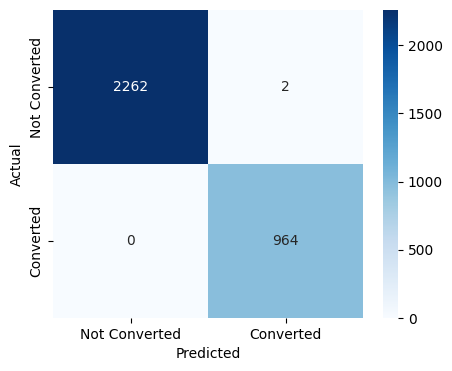

```python
rf_train_perf = model_performance_classification(rf_model, X_train, y_train)
display(rf_train_perf)
confusion_matrix_sklearn(rf_model, X_train, y_train)
```

**Model Performance Observations**

- The model achieved an extremely high **accuracy of 99.94%**.
- The **recall is 1.00**, meaning the model correctly identified all actual positive cases in the evaluated data.
- The **precision is 99.79%**, meaning almost all predicted positive cases were truly positive.
- The **F1-score is 99.90%**, showing an excellent balance between precision and recall.
- These results suggest the model is performing almost perfectly.
- However, the scores are unusually high, so it is important to check for possible **data leakage**, duplicate-like information, or preprocessing mistakes.
- The model should also be validated on unseen test data or cross-validation results to confirm that the performance is genuine.

### Checking model performance on test set

|  | Accuracy | Recall | Precision | F1 |
| --- | --- | --- | --- | --- |
| 0 | 0.859104 | 0.723971 | 0.786842 | 0.754098 |

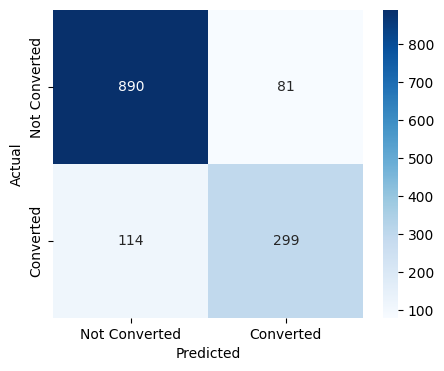

```python
rf_test_perf = model_performance_classification(rf_model, X_test, y_test)
display(rf_test_perf)
confusion_matrix_sklearn(rf_model, X_test, y_test)
```

**Model Performance Observations**

- The model achieved an **accuracy of 85.91%**, which is much better than the majority-class baseline of about **70%**.
- The **recall is 72.40%**, meaning the model correctly identifies about 72 out of every 100 actual positive cases.
- The **precision is 78.68%**, meaning most predicted positives are truly positive.
- The **F1-score is 75.41%**, showing a reasonable balance between precision and recall.
- Compared with the earlier near-perfect result, this performance looks more realistic and less likely to be affected by leakage.
- Since the dataset is moderately imbalanced, the **F1-score and recall** are more informative than accuracy alone.
- Overall, the model performs well, but there is still room to improve recall if identifying positive cases is the main goal.

## AdaBoost Classifier

```python
adaboost_model = Pipeline(
    steps=[
        ("preprocessor", preprocessor),
        (
            "model",
            AdaBoostClassifier(
                estimator=DecisionTreeClassifier(max_depth=1, random_state=1),
                random_state=1,
                n_estimators=100,
                learning_rate=0.1,
            ),
        ),
    ]
)

adaboost_model.fit(X_train, y_train)
```

```
Pipeline(steps=[('preprocessor',
                 ColumnTransformer(transformers=[('num', StandardScaler(),
                                                  ['age', 'website_visits',
                                                   'time_spent_on_website',
                                                   'page_views_per_visit']),
                                                 ('cat',
                                                  OneHotEncoder(handle_unknown='ignore'),
                                                  ['current_occupation',
                                                   'first_interaction',
                                                   'profile_completed',
                                                   'last_activity',
                                                   'print_media_type1',
                                                   'print_media_type2',
                                                   'digital_media',
                                                   'educational_channels',
                                                   'referral'])])),
                ('model',
                 AdaBoostClassifier(estimator=DecisionTreeClassifier(max_depth=1,
                                                                     random_state=1),
                                    learning_rate=0.1, n_estimators=100,
                                    random_state=1))])
```

### Checking model performance on training set

|  | Accuracy | Recall | Precision | F1 |
| --- | --- | --- | --- | --- |
| 0 | 0.810099 | 0.558091 | 0.742069 | 0.637063 |

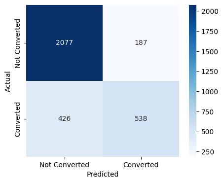

```python
adaboost_train_perf = model_performance_classification(adaboost_model, X_train, y_train)
display(adaboost_train_perf)
confusion_matrix_sklearn(adaboost_model, X_train, y_train)
```

**Model Performance Observations**

- The model achieved an **accuracy of 81.01%**, which is above the majority-class baseline of about **70%**.
- The **recall is 55.81%**, meaning the model is missing a fairly large number of actual positive cases.
- The **precision is 74.21%**, so when the model predicts a positive case, it is usually correct.
- The **F1-score is 63.71%**, indicating a moderate balance between precision and recall.
- Compared with the previous model, this model performs worse across all key metrics, especially recall.
- The lower recall suggests the model is more conservative in predicting class `1`.
- If the business goal is to identify as many positive cases as possible, this model may not be the best choice.

### Checking model performance on test set

|  | Accuracy | Recall | Precision | F1 |
| --- | --- | --- | --- | --- |
| 0 | 0.825145 | 0.585956 | 0.773163 | 0.666667 |

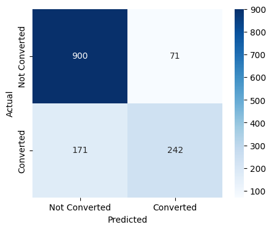

```python
adaboost_test_perf = model_performance_classification(adaboost_model, X_test, y_test)
display(adaboost_test_perf)
confusion_matrix_sklearn(adaboost_model, X_test, y_test)
```

**Model Performance Observations**

- The model achieved an **accuracy of 82.51%**, which is better than the majority-class baseline of about **70%**.
- The **recall is 58.60%**, meaning the model identifies only a little over half of the actual positive cases.
- The **precision is 77.32%**, showing that most predicted positive cases are correct.
- The **F1-score is 66.67%**, indicating a moderate balance between precision and recall.
- Compared with the previous model, this one performs slightly better in all metrics.
- However, compared with the stronger model that had **85.91% accuracy** and **75.41% F1-score**, this model is weaker.
- The model is still relatively conservative, as recall remains below 60%.
- If capturing positive cases is important, this model may need threshold tuning, class balancing, or a stronger algorithm.